# R tutorial

Yu-Teng Chen

2019年7月7日

# Chapter 1 - Basic Introduction

- 1. 熟練Rstudio的基本操作包含運用,視覺化操作與模擬分析。
- 2. R為統計領域中使用率最頻繁的軟體之一,TIOBE對全球城市語言排名中R佔第10名,但由於mac與windows的R介面與快捷鍵不同,而Rstudio介面相似,且融入了許多其他程式碼(LaTeX,C,…)與套件(RMarkDown,…),並介面也較方便,因此Rstudio的使用率也漸頻繁。

#### R studio 頁面介紹

##### R studio主要分為四大區塊

##### 1. 左上區為R Script，若想新增編輯頁面可點選左上角的「+」選R Script（windows快捷鍵為ctrl + shift + N ， Mac為 command + shift + N）。

##### 2. 左下區R的執行介面(Console)，在編輯區塊所執行的指令都會在左下角顯現，也可以在此執行指令。

##### 3. 右上區(Environment)像是倉庫一樣，儲存了匯入及創造出宣告的資料，執行過的命令也會記錄下來。

##### 4. 右下區則包含Files、Plots、Packages、Help、Viewer，可以查看繪製的圖也可以查詢不懂的指令。

[figure not shown]

## 1.1 Introduction to R

##### *通常給R 的指令分成兩種，一個 expression，或是一個 assignment。*

##### Expression

##### 在R中，每一段指令都是一個expression。

##### 輸入有效的expression後，R會執行並且把結果呈現於 Console 中。

##### Assignment

##### 物件(object)被assign(賦值)後，會出現在Environment中。

##### 物件可以是一個變數、數字、文字、向量、函數或是只是宣告變數類型的空集合，甚至是其他更複雜的形式。

##### Others

##### 在編輯時可以使用「#」來新增註解，該行所有在「#」之後輸入的內容都會在R執行時所略過。

### 基本數學運算

```r
#加 ;   減   ;  乘  ;   除
1+3 ; 10-5 ; 3 * 2 ; 6 / 3
```

```
## [1] 4
```

```
## [1] 5
```

```
## [1] 6
```

```
## [1] 2
```

```r
#以上都為Expresstion
```

#### 次方、立方、平方根

```r
#3的平方 ;   3的1/3次方   ;  根號2
3^2     ;     3^(1/3)    ; sqrt(2)
```

```
## [1] 9
```

```
## [1] 1.44225
```

```
## [1] 1.414214
```

#### log

```r
#以e為底取log ;   log2代表2為底
log(65)      ;    log2(10)
```

```
## [1] 4.174387
```

```
## [1] 3.321928
```

#### 特殊字元 $\pi ; e$

```r
pi      ;    exp(1)
```

```
## [1] 3.141593
```

```
## [1] 2.718282
```

#### 小數位數取捨

```r
#四捨五入  ; 到小數點第2位 ;   無條件捨去 ;   無條件進位 ;   絕對值
round(4.6) ; round(4.784,2) ; floor(4.7) ;ceiling(4.7) ; abs(-3.2)
```

```
## [1] 5
```

```
## [1] 4.78
```

```
## [1] 4
```

```
## [1] 5
```

```
## [1] 3.2
```

### 基本統計量

```r
x <- c(1 ,2 ,3 ,4) # 等同於 x <- 1:4
#這就是assignment
```

```r
#總和  ; 平均數  ; 中位數   ; 變異數  ; 標準差  ; 小結論
sum(x) ; mean(x) ; median(x) ; var(x) ; sd(x) ;summary(x)
```

```
## [1] 10
```

```
## [1] 2.5
```

```
## [1] 2.5
```

```
## [1] 1.666667
```

```
## [1] 1.290994
```

```
##    Min. 1st Qu.  Median    Mean 3rd Qu.    Max.
##    1.00    1.75    2.50    2.50    3.25    4.00
```

```r
cumsum(x) #累加
```

```
## [1]  1  3  6 10
```

```r
cumprod(x) #累乘(可以算階層)
```

```
## [1]  1  2  6 24
```

# Chapter 2 - R的物件

##### 在 R 中，每一樣**變數或函數**，都叫做**物件**，這物件主要包含了「vector」、「matrix」、「data frame」和「list」，而這些物件主要都是資料處理時會遇到的資料型態，並且每個資料型態都有其對應的指令，學會運用他們對於資料處理可以更加熟練。

##### 在開始介紹各種類型的物件時，先跟大家介紹如何辨別物件是屬於哪種類型的

## 2.0 資料結構、類別、屬性

以R內建IRIS資料為例

```r
#結構
str(iris)
```

```
## 'data.frame':    150 obs. of  5 variables:
##  $ Sepal.Length: num  5.1 4.9 4.7 4.6 5 5.4 4.6 5 4.4 4.9 ...
##  $ Sepal.Width : num  3.5 3 3.2 3.1 3.6 3.9 3.4 3.4 2.9 3.1 ...
##  $ Petal.Length: num  1.4 1.4 1.3 1.5 1.4 1.7 1.4 1.5 1.4 1.5 ...
##  $ Petal.Width : num  0.2 0.2 0.2 0.2 0.2 0.4 0.3 0.2 0.2 0.1 ...
##  $ Species     : Factor w/ 3 levels "setosa","versicolor",..: 1 1 1 1 1 1 1 1 1 1 ...
```

```r
#類別
class(iris)
```

```
## [1] "data.frame"
```

```r
#屬性
attributes(iris)
```

```
## $names
## [1] "Sepal.Length" "Sepal.Width"  "Petal.Length" "Petal.Width"
## [5] "Species"
##
## $class
## [1] "data.frame"
##
## $row.names
##   [1]   1   2   3   4   5   6   7   8   9  10  11  12  13  14  15  16  17
##  [18]  18  19  20  21  22  23  24  25  26  27  28  29  30  31  32  33  34
##  [35]  35  36  37  38  39  40  41  42  43  44  45  46  47  48  49  50  51
##  [52]  52  53  54  55  56  57  58  59  60  61  62  63  64  65  66  67  68
##  [69]  69  70  71  72  73  74  75  76  77  78  79  80  81  82  83  84  85
##  [86]  86  87  88  89  90  91  92  93  94  95  96  97  98  99 100 101 102
## [103] 103 104 105 106 107 108 109 110 111 112 113 114 115 116 117 118 119
## [120] 120 121 122 123 124 125 126 127 128 129 130 131 132 133 134 135 136
## [137] 137 138 139 140 141 142 143 144 145 146 147 148 149 150
```

## 2.1 向量(c( ) ; concatenate)

### 數值向量(numeric vector)

```r
class(c(7,8,9)) #class()是判斷類別
```

```
## [1] "numeric"
```

### 字串向量(character vector)

```r
class(c("政大統研","暑期工作坊"))
```

```
## [1] "character"
```

### 布林向量(logical vector)

```r
class(c(TRUE,FALSE))
```

```
## [1] "logical"
```

### 向量的運算

#### 向量+向量

##### 在 R 中，大部份的運算都是向量式的。

##### 當多組向量在進行運算時，會由相對應位置的元素進行運算。

##### 當相加的兩個向量長度不同時，R會自動重複比較短的向量，補到和較長的向量相同的長度，然後用 一樣的方式去做計算。

```r
c(1,2,3)+c(1:3)
```

```
## [1] 2 4 6
```

```r
2+c(1,2,3)
```

```
## [1] 3 4 5
```

```r
c(1,2)+c(1,2,3,4)
```

```
## [1] 2 4 4 6
```

```r
c(1,3)+c(1,2,3)
```

```
## [1] 2 5 4
```

```r
x <- c(1,2,3) ; y <- c(3,6,9) #賦值
x+y  ;  x*y  ;  y/x
```

```
## [1]  4  8 12
```

```
## [1]  3 12 27
```

```
## [1] 3 3 3
```

## 2.2 矩陣（Matrix）

> - Matrix如同線性代數中學的，有列有行，存放一定是數值(numeric)
> - Matrix可以由一長串的向量去轉換而成，告訴他維度即可

```r
## 1 ~ 12的打法可以打 下限:上限
1:12
```

```
##  [1]  1  2  3  4  5  6  7  8  9 10 11 12
```

```r
(x1 = matrix(1 : 12 ,ncol = 6) )
```

```
##      [,1] [,2] [,3] [,4] [,5] [,6]
## [1,]    1    3    5    7    9   11
## [2,]    2    4    6    8   10   12
```

```r
#ncol代表要有6行
```

```r
(x2 = matrix(1 : 12 ,ncol = 6, byrow = T) )
```

```
##      [,1] [,2] [,3] [,4] [,5] [,6]
## [1,]    1    2    3    4    5    6
## [2,]    7    8    9   10   11   12
```

```r
#byrow依據列給值
```

```r
(y1 = matrix(1 : 4 ,nrow = 2) )
```

```
##      [,1] [,2]
## [1,]    1    3
## [2,]    2    4
```

```r
#nrow代表要有2列
```

```r
(y2 = matrix(1 : 4 ,nrow = 2, byrow = T) )
```

```
##      [,1] [,2]
## [1,]    1    2
## [2,]    3    4
```

```r
#byrow依據列給值
```

### 轉置矩陣 與 反矩陣

```r
t(x1) # 轉置(transpose)
```

```
##      [,1] [,2]
## [1,]    1    2
## [2,]    3    4
## [3,]    5    6
## [4,]    7    8
## [5,]    9   10
## [6,]   11   12
```

```r
solve(y1) #反矩陣
```

```
##      [,1] [,2]
## [1,]   -2  1.5
## [2,]    1 -0.5
```

### 矩陣乘法 與 對應元素相乘

```r
x1
```

```
##      [,1] [,2] [,3] [,4] [,5] [,6]
## [1,]    1    3    5    7    9   11
## [2,]    2    4    6    8   10   12
```

```r
t(x1) %*% x1 #矩陣的乘法
```

```
##      [,1] [,2] [,3] [,4] [,5] [,6]
## [1,]    5   11   17   23   29   35
## [2,]   11   25   39   53   67   81
## [3,]   17   39   61   83  105  127
## [4,]   23   53   83  113  143  173
## [5,]   29   67  105  143  181  219
## [6,]   35   81  127  173  219  265
```

```r
x1 * x1   # t(x1) * x1 不能跑，因為兩個物件維度不一樣
```

```
##      [,1] [,2] [,3] [,4] [,5] [,6]
## [1,]    1    9   25   49   81  121
## [2,]    4   16   36   64  100  144
```

## 2.3 Data Frame

> - Data.frame內存放一大堆變數(行向量), 變數間型態可以不同
> - 限制：變數間長度必須一樣
> - 最常使用的物件形式(相當於SAS的Dataset)

```r
data <- data.frame(x1=c(1,2,3), #若要換行則此逗號要擺這
                   x2=c('a','b','c'))
data  ;  class(data)
```

```
##   x1 x2
## 1  1  a
## 2  2  b
## 3  3  c
```

```
## [1] "data.frame"
```

```r
data <- data.frame(x1=c(1,2,3,4),
                   x2=c('a','b','c')) #變數間長度必須一樣
```

```
## Error in data.frame(x1 = c(1, 2, 3, 4), x2 = c("a", "b", "c")) :
  arguments imply differing number of rows: 4, 3
```

### Dataframe取值

> - 利用[i,j] 來對 dataframe 進行取值的動作，其中， i 為列數、 j 為行數
> - [i,] 表示取出 dataframe 中第 i 列的所有資料，包含所有行變數
> - [,j] 表示取出 dataframe 中第 j 行的所有資料，包含所有列資料
> - $ (錢字號)這裡可以用來挑選特定欄位！記得搭配tab鍵讓你事半功倍！

```r
## Data.frame
data <- data.frame(class=c('SQL','R','Python'),
                   grade=c(100,100,100),
                   handsome=c(F,T,F))
data
```

```
##    class grade handsome
## 1    SQL   100    FALSE
## 2      R   100     TRUE
## 3 Python   100    FALSE
```

```r
## 從data中取出課程的變數(欄位、向量、抽屜)
data$class ; data[,1]
```

```
## [1] SQL    R      Python
## Levels: Python R SQL
```

```
## [1] SQL    R      Python
## Levels: Python R SQL
```

```r
## 從data中取出成績的變數(欄位、向量、抽屜)
data$grade ; data[,2]
```

```
## [1] 100 100 100
```

```
## [1] 100 100 100
```

```r
## 從data中取出 True
data[2,3]
```

```
## [1] TRUE
```

## 2.4 List

> - 彈性較大的物件，想像成一種Data.frame，但允許變數長度不同
> - Data.frame 為 List 的一種特例 : 長度相同

```r
lst <- list(A=c(1:5),
            B=c('a','b'))
lst
```

```
## $A
## [1] 1 2 3 4 5
##
## $B
## [1] "a" "b"
```

### List取值

> - [i]：取出 list 中的第 i 個物件，注意！取出來的物件依舊是 list 結構！
> - [[i]]：取出第 i 個物件中的全部元素，注意！[[]]會破壞原本的 list 結構！
> - [[i]][j]：取出第 i 個物件中的第j個元素
> - 若物件已命名，可以利用 $ (錢字號)來提取物件

```r
## List
data <- list(class=c('SQL','R','Python'),
             grade=c(100,100,100),
             handsome=c(F,T,F))
data
```

```
## $class
## [1] "SQL"    "R"      "Python"
##
## $grade
## [1] 100 100 100
##
## $handsome
## [1] FALSE  TRUE FALSE
```

```r
## 從data中取出class的變數(欄位、向量、抽屜)
## 只是今天衣櫃的每個抽屜長度可以不一樣
data$class
```

```
## [1] "SQL"    "R"      "Python"
```

```r
data[1]  # 仍然是list格式
```

```
## $class
## [1] "SQL"    "R"      "Python"
```

```r
data[[1]]
```

```
## [1] "SQL"    "R"      "Python"
```

```r
data[[1]][2]
```

```
## [1] "R"
```

## 2.5 特別的物件

### NA(**N**ot **A**valiable)

> - 未來資料中一定常常碰到NA

```r
## NA常常就像這樣任性的存在
x <- c(1,2,3,NA,5)
y <- c(1,2,NA,4,5)
```

```r
## NA只要碰到加減乘除就會無效
x + y
```

```
## [1]  2  4 NA NA 10
```

```r
mean(x)
```

```
## [1] NA
```

```r
## 只要把缺憾移除掉人生就美好多了
mean(x,na.rm=T)
```

```
## [1] 2.75
```

```r
## 通常NA有規則可以填補我們就會補起來
x[4] <- 4
```

```r
## 但往往你需要更聰明的方式去補而不是傻傻的數
## is.na可以回傳變數哪一個位置為NA
is.na(y)
```

```
## [1] FALSE FALSE  TRUE FALSE FALSE
```

```r
y[ is.na(y) ] <- 3 #直接填NA為3
```

### Inf

```r
my.money <- c(0,100,Inf) ; your.money <- c(-Inf,10,0)
my.money+your.money
```

```
## [1] -Inf  110  Inf
```

```r
my.money/your.money ## 我也不知道為什麼 Inf/0會=Inf，可能要問數學老師
```

```
## [1]   0  10 Inf
```

### NaN(**N**ot a **N**umber)

```r
0/0 ; 1/0-1/0
```

```
## [1] NaN
```

```
## [1] NaN
```

# Chapter 3 - 常用的技巧

## 3.1 看部分資料

```r
head(iris,3)  # 若不指定後面數字，預設為看前六行
```

```
##   Sepal.Length Sepal.Width Petal.Length Petal.Width Species
## 1          5.1         3.5          1.4         0.2  setosa
## 2          4.9         3.0          1.4         0.2  setosa
## 3          4.7         3.2          1.3         0.2  setosa
```

```r
tail(iris,3)  # 若不指定後面數字，預設為看後六行
```

```
##     Sepal.Length Sepal.Width Petal.Length Petal.Width   Species
## 148          6.5         3.0          5.2         2.0 virginica
## 149          6.2         3.4          5.4         2.3 virginica
## 150          5.9         3.0          5.1         1.8 virginica
```

## 3.2 擷取部分資料

```r
data <- iris[1:6, 1:5] #賦值給data
data ; class(data)
```

```
##   Sepal.Length Sepal.Width Petal.Length Petal.Width Species
## 1          5.1         3.5          1.4         0.2  setosa
## 2          4.9         3.0          1.4         0.2  setosa
## 3          4.7         3.2          1.3         0.2  setosa
## 4          4.6         3.1          1.5         0.2  setosa
## 5          5.0         3.6          1.4         0.2  setosa
## 6          5.4         3.9          1.7         0.4  setosa
```

```
## [1] "data.frame"
```

## 3.3 改資料欄位名字

```r
names(data)  #看現在欄位的名字
```

```
## [1] "Sepal.Length" "Sepal.Width"  "Petal.Length" "Petal.Width"
## [5] "Species"
```

```r
names(data) <- c('花萼長', '花萼寬', '花瓣長', '花瓣寬', '品種')
names(data)
```

```
## [1] "花萼長" "花萼寬" "花瓣長" "花瓣寬" "品種"
```

## 3.4 新增欄列、刪除欄列

```r
# 刪除第五欄
data[,-5]
```

```
##   花萼長 花萼寬 花瓣長 花瓣寬
## 1    5.1    3.5    1.4    0.2
## 2    4.9    3.0    1.4    0.2
## 3    4.7    3.2    1.3    0.2
## 4    4.6    3.1    1.5    0.2
## 5    5.0    3.6    1.4    0.2
## 6    5.4    3.9    1.7    0.4
```

```r
new <- c('a','b','c','d','e','f')
cbind(data, new)  # 增加第六欄
```

```
##   花萼長 花萼寬 花瓣長 花瓣寬   品種 new
## 1    5.1    3.5    1.4    0.2 setosa   a
## 2    4.9    3.0    1.4    0.2 setosa   b
## 3    4.7    3.2    1.3    0.2 setosa   c
## 4    4.6    3.1    1.5    0.2 setosa   d
## 5    5.0    3.6    1.4    0.2 setosa   e
## 6    5.4    3.9    1.7    0.4 setosa   f
```

```r
# 刪除第六列
data[-6,]
```

```
##   花萼長 花萼寬 花瓣長 花瓣寬   品種
## 1    5.1    3.5    1.4    0.2 setosa
## 2    4.9    3.0    1.4    0.2 setosa
## 3    4.7    3.2    1.3    0.2 setosa
## 4    4.6    3.1    1.5    0.2 setosa
## 5    5.0    3.6    1.4    0.2 setosa
```

```r
new = c(5.2 , 3.1, 1.1, 0.3, 'setosa')
rbind(data, new)  # 增加第七列
```

```
##   花萼長 花萼寬 花瓣長 花瓣寬   品種
## 1    5.1    3.5    1.4    0.2 setosa
## 2    4.9      3    1.4    0.2 setosa
## 3    4.7    3.2    1.3    0.2 setosa
## 4    4.6    3.1    1.5    0.2 setosa
## 5      5    3.6    1.4    0.2 setosa
## 6    5.4    3.9    1.7    0.4 setosa
## 7    5.2    3.1    1.1    0.3 setosa
```

## 3.5 看資料維度 與 資料結構

```r
dim(data)
```

```
## [1] 6 5
```

```r
str(data)  # attributes(data)
```

```
## 'data.frame':    6 obs. of  5 variables:
##  $ 花萼長: num  5.1 4.9 4.7 4.6 5 5.4
##  $ 花萼寬: num  3.5 3 3.2 3.1 3.6 3.9
##  $ 花瓣長: num  1.4 1.4 1.3 1.5 1.4 1.7
##  $ 花瓣寬: num  0.2 0.2 0.2 0.2 0.2 0.4
##  $ 品種  : Factor w/ 3 levels "setosa","versicolor",..: 1 1 1 1 1 1
```

## 3.6 更改某一欄

```r
data$品種 <-  "某一種花"
data
```

```
##   花萼長 花萼寬 花瓣長 花瓣寬     品種
## 1    5.1    3.5    1.4    0.2 某一種花
## 2    4.9    3.0    1.4    0.2 某一種花
## 3    4.7    3.2    1.3    0.2 某一種花
## 4    4.6    3.1    1.5    0.2 某一種花
## 5    5.0    3.6    1.4    0.2 某一種花
## 6    5.4    3.9    1.7    0.4 某一種花
```

## 3.7 選取特定的資料（列）

```r
## 選擇 花萼長 >= 5 的資料(列)
(index <- data$花萼長 >= 5)
```

```
## [1]  TRUE FALSE FALSE FALSE  TRUE  TRUE
```

```r
data[index,]
```

```
##   花萼長 花萼寬 花瓣長 花瓣寬     品種
## 1    5.1    3.5    1.4    0.2 某一種花
## 5    5.0    3.6    1.4    0.2 某一種花
## 6    5.4    3.9    1.7    0.4 某一種花
```

# 練習一

## 1. matrix 的製作與運算

##### 大家都知道回歸分析中估計係數常使用最小平方法，公式為$(X^{'}X)^{-1}X^{'}Y$，如果已知$X$、$Y$分別是下面這兩個，請使用Ｒ套入公式計算出答案

```r
X  ;  Y  #請宣告兩個變量X、Y，分別代表下面的X矩陣和Y矩陣
```

```
##      [,1] [,2]
## [1,]    1    1
## [2,]    0    2
## [3,]    1    0
```

```
##      [,1]
## [1,]   13
## [2,]   -2
## [3,]    1
```

## 2. list 製作與運用

##### 你能將左邊資料變成右邊資料嗎？

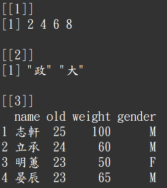

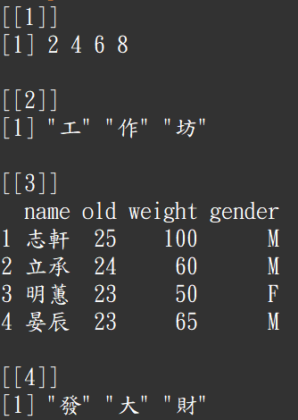

# Chapter 4 - 常用的函數

##### 接下的部份是跟大家介紹幾個較常用的函數

##### 但實際上絕對還會用到更多更多的函數

##### 所以本課程不涵蓋的部份還請各位去詢問Google大大

## 4.1 ?in R

##### 忘記一個function的用法時常常用?來查詢

##### 或是用help()

```r
?mean
help(mean)
```

## 4.2 length

##### 看一個向量長度時常用length

```r
length(c(1:10))
```

```
## [1] 10
```

## 4.3 sort, order, rank

##### sort：將向量元素從小排到大

##### order：再以從小排到大的結果下，「排名結果」依序對應至原本向量中的第幾個「位置」

##### rank : 由小到大排列的情況下，每個元素依序「排名」第幾

```r
set.seed(10)
(x <- sample(1:10,7)) #隨機抽7個1到10的數字
```

```
## [1] 6 3 4 5 1 2 7
```

```r
sort(x)
```

```
## [1] 1 2 3 4 5 6 7
```

```r
order(x)
```

```
## [1] 5 6 2 3 4 1 7
```

```r
rank(x)
```

```
## [1] 6 3 4 5 1 2 7
```

## 4.4 seq, rep

##### seq 可以想成產生一連串有規律的數字(ex:等差數列)

- ##### ?seq ==> seq(from = 1, to = 1, …)

##### rep 可以想成產生一連串有重複的數字

##### ?rep ==> rep(x, … )

##### 常常seq跟rep會一起搭配

```r
seq(from = 1, to = 9, by = 2) ## seq(1,9,2)
```

```
## [1] 1 3 5 7 9
```

```r
seq(from = 9, to = 1, by = -2) ## seq(9,1,-2)
```

```
## [1] 9 7 5 3 1
```

```r
rep( seq(from = 1, to = 9, by = 2) , times= 2)
```

```
##  [1] 1 3 5 7 9 1 3 5 7 9
```

```r
rep( seq(from = 1, to = 9, by = 2) , each= 2)
```

```
##  [1] 1 1 3 3 5 5 7 7 9 9
```

```r
rep(seq(from = 1, to = 9, by = 2) , each = 3 , times = 2)
```

```
##  [1] 1 1 1 3 3 3 5 5 5 7 7 7 9 9 9 1 1 1 3 3 3 5 5 5 7 7 7 9 9 9
```

## 4.5 邏輯判斷

### 常用的邏輯判斷符號

##### **<**、**>** ： 小於、大於。

##### **<=**、**>=** ： 小於等於、大於等於。

##### **==** ： 等於。

##### **!=** ： 不等於。

##### **&** ： 交集（且）。

##### **|** ： 聯集（或）。

##### A **%in%** B ： A是否在B內。

```r
3 > 2 ; 3 < 2
```

```
## [1] TRUE
```

```
## [1] FALSE
```

```r
3 >= 5 ; 3 <= 5
```

```
## [1] FALSE
```

```
## [1] TRUE
```

```r
# 你可以key 2 = 3  看看
2 == 3  ; 2 != 3
```

```
## [1] FALSE
```

```
## [1] TRUE
```

```r
data
```

```
##   花萼長 花萼寬 花瓣長 花瓣寬     品種
## 1    5.1    3.5    1.4    0.2 某一種花
## 2    4.9    3.0    1.4    0.2 某一種花
## 3    4.7    3.2    1.3    0.2 某一種花
## 4    4.6    3.1    1.5    0.2 某一種花
## 5    5.0    3.6    1.4    0.2 某一種花
## 6    5.4    3.9    1.7    0.4 某一種花
```

```r
data$花瓣長 < 5 & data$花瓣長 > 4.6    # 知道true and false 就可以抓出特定資料
```

```
## [1] FALSE FALSE FALSE FALSE FALSE FALSE
```

```r
data$花瓣長 > 5 & data$花瓣寬 == 0.2
```

```
## [1] FALSE FALSE FALSE FALSE FALSE FALSE
```

```r
## 看物件是否有包含在裡面
c(2,5) %in% c(1:3)
```

```
## [1]  TRUE FALSE
```

### if else

##### ifelse簡易語法

##### ifelse(條件式, A(TRUE) , B(FALSE) )

##### 如果條件式判斷為TRUE，則為A

##### 如果條件式判斷為FALSE，則為B

```r
ifelse( 3 > 2 , 3 + 2 , 3 - 2 ) #如果3>2成立，則執行3+2，否則執行3-2
```

```
## [1] 5
```

### 條件執行

- if ( A條件式 ){  
  A條件式判斷為TRUE，則執行此區塊  
  }else if ( B條件式 ){  
  A條件式判斷為FALSE，且B條件式判斷為TRUE，則執行此區塊  
  }else{  
  A條件式和B條件式皆判斷為FALSE，則執行此區塊}

```r
if(3 < 2){
  3 + 2               # 如果 "3 < 2" 為TRUE，則執行3 + 2
}else if (3 == 2){
  3 * 2               # 否則如果 "3 == 2" 為TRUE，則執行3 * 2
}else{
  3 - 2               # 如果 "3 < 2"和 "3 == 2" 皆為FALSE，則執行3 - 2
}
```

```
## [1] 1
```

### 迴圈結構

擁 有 了 他 ， 就 擁 有 了 半 個 世 界

### for迴圈

##### for(variable in iterator) {Expressions}

##### variable : 宣告一個變量

##### iterator : 疊代器，用來宣告遞迴過程中變量要依序變換的值，

##### 也就宣告一個遞迴用的「向量」Expressions :可以跟variable有關或無關的運算

```r
x <- 0
for(i in 1:5){
  x <- x + i
  print(x)
}
```

```
## [1] 1
## [1] 3
## [1] 6
## [1] 10
## [1] 15
```

```r
x
```

```
## [1] 15
```

## 4.6 which

##### which是一個很常用的function

##### which可以理解為：哪一個為TURE

##### which更常拿來挑選資料

```r
which(c('a', 'b', 'c') == 'b') #哪個位置為b
```

```
## [1] 2
```

```r
set.seed(1)
(x = rnorm(20)) #隨機生成20個值，服從normal分配
```

```
##  [1] -0.62645381  0.18364332 -0.83562861  1.59528080  0.32950777
##  [6] -0.82046838  0.48742905  0.73832471  0.57578135 -0.30538839
## [11]  1.51178117  0.38984324 -0.62124058 -2.21469989  1.12493092
## [16] -0.04493361 -0.01619026  0.94383621  0.82122120  0.59390132
```

```r
which(x > 1)   # 誰大於1
```

```
## [1]  4 11 15
```

```r
sum(x > 1)     # 有多少筆大於1
```

```
## [1] 3
```

```r
x[x>1]         # 挑出大於1的
```

```
## [1] 1.595281 1.511781 1.124931
```

## 4.7 自定function

##### 有時候我們會需要自定一個function來完成某些事情

##### 這邊教大家如何寫一個自己的function

##### 假設我們沒有計算算平均數的function，我們要自己寫一個

```r
calcu.mean <- function(x){
  mean.result <- sum(x)/length(x)
  return(mean.result)
}

calcu.mean(1:10)
```

```
## [1] 5.5
```

```r
## It's same
mean(1:10)
```

```
## [1] 5.5
```

## 4.8 字串處理：nchar, strsplit ,substr, paste

##### 字串常常是很棘手的難題

##### 例如：台北市文山區指南路三段….

##### 也許我們想保留的只有台北市文山區或是指南路三段

##### 這時候就會對字串做些處理

```r
x <- c("ABC-88", "WTF-0978" , "YTC-0857")
```

```r
## 計算字數(長度)
nchar(x)
```

```
## [1] 6 8 8
```

```r
## 切割英文跟數字(分割)
strsplit(x, split = "-") #根據 "-" 切割
```

```
## [[1]]
## [1] "ABC" "88"
##
## [[2]]
## [1] "WTF"  "0978"
##
## [[3]]
## [1] "YTC"  "0857"
```

```r
## 字串的擷取
substr(x = x[1] , start = 1 , stop = 5) #從第一個到第五個
```

```
## [1] "ABC-8"
```

```r
## 字串的剪貼
paste(substr(x[2],1,7),substr(x[3],5,7), sep = "-") #根據"-"貼起來
```

```
## [1] "WTF-097-085"
```

```r
paste0(substr(x[2],1,7),substr(x[3],5,7)) #無縫剪貼
```

```
## [1] "WTF-097085"
```

## 4.9 變數種類的轉換

##### 有時候資料並非為我們預想中的資料型態，因此我們需要做轉換

### as.character

##### 轉成character型態

```r
x <- c(1,2,3)
as.character(x)
```

```
## [1] "1" "2" "3"
```

### as.numeric

##### 轉成numeric型態

##### 若轉換過去沒有對應到數字則會出現NA

##### 注意factor ==> numeric

```r
x <- c('1','2')
as.numeric(x)
```

```
## [1] 1 2
```

```r
y <- c('1','a')
as.numeric(y)
```

```
## [1]  1 NA
```

```r
z <- factor(c('a','b','c'))
as.numeric(z)
```

```
## [1] 1 2 3
```

```r
z1 <- factor(c('a','b','c'),levels=c('c','b','a'))
as.numeric(z1)
```

```
## [1] 3 2 1
```

```r
w <- factor(c('4','5','6'))
as.numeric(w)
```

```
## [1] 1 2 3
```

##### *注意：若是要由factor轉為numeric，須先轉成character再轉成numeric*

```r
w <- factor(c('4','5','6'))
as.numeric( as.character(w) )
```

```
## [1] 4 5 6
```

### as.factor

```r
x <- c(1,2,3)
as.factor(x)
```

```
## [1] 1 2 3
## Levels: 1 2 3
```

```r
y <- c('a','b','c')
as.factor(y)
```

```
## [1] a b c
## Levels: a b c
```

# 練習二

## 1. data frame 製作與運用 與 資料型態變化

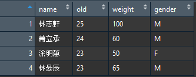

## 2. if與else 運用

##### 你能將左邊資料變成右邊資料嗎？

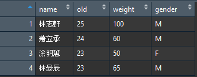

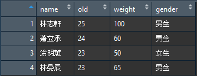

## 3. 文字運用

##### 你能將上題結果變成下面資料嗎？

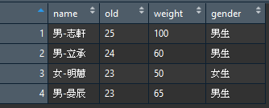